# Création de cartes choroplèthes avec {ggplot2}

### 0.7.2 Mise à l’échelle des Couleurs Discrete

‣ Passez à la mise à l’échelle des couleurs discrètes en catégorisant d’abord nos données en fonction des niveaux de risque, puis en appliquant les couleurs appropriées..

```r
# Créer de catégories de risque pour nos données
malaria2 %>%
  mutate(risk = case_when(
    cases_2021 < quantile(cases_2021, 0.5) ~ 'low',
    cases_2021 > quantile(cases_2021, 0.75) ~ 'high',
    TRUE ~ 'medium'
  )) -> malaria3

table(malaria3$risk)
```

```
##
##   high    low medium
##      9     18     10
```

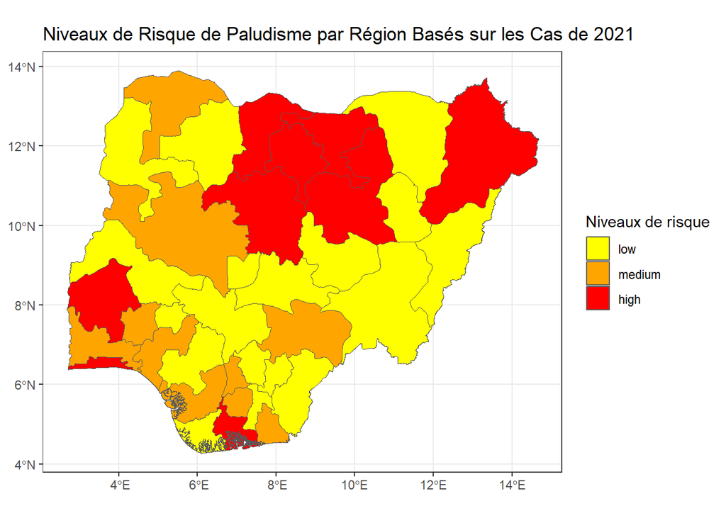

```r
# Créer une palette de couleurs manuelle
custom_palette <- c("yellow", "orange", "red")

# Appliquer la palette personnalisée
ggplot(data = malaria3) +
  geom_sf(aes(fill = fct_reorder(risk, cases_2021))) +
  scale_fill_manual(values = custom_palette, name = "Niveaux de risque") +
  ggtitle("Niveaux de Risque de Paludisme par Région Basés sur les Cas de 2021") +
  theme_bw()
```

‣ Les régions sont maintenant distinctement colorées en fonction des niveaux de risque : Faible, Moyen et Élevé.

## 0.8 Temps de pratique 2 : Créez votre propre palette de couleurs

‣ Affichez les cas de paludisme au Nigeria pour 2000 en utilisant cette palette de couleurs personnalisée.

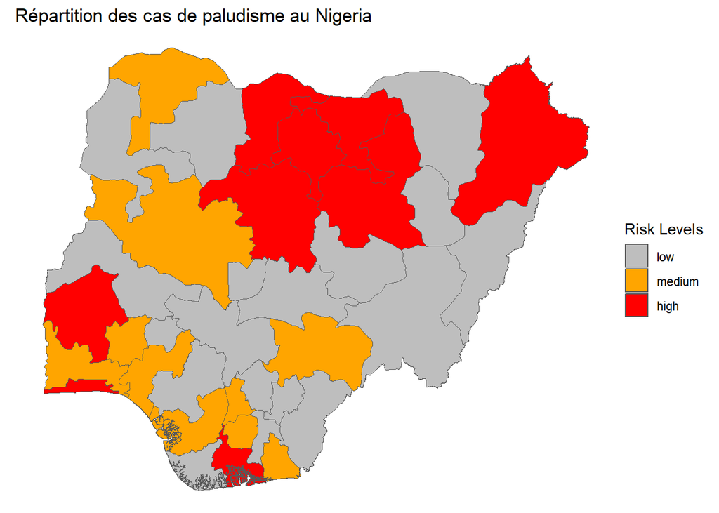

```r
new_palette <- c("gray", "orange", "red") # Définir un nouvel ensemble de couleurs

ggplot(data=malaria3) +
   geom_sf(aes(fill =  fct_reorder(risk, cases_2000))) + # Réordonner les étiquettes de risque selon les cas de l'année 2000
   scale_fill_manual(values = new_palette, "Risk Levels") +
   labs(title = "Répartition des cas de paludisme au Nigeria",
        fill = "Nombre de cas",
        x = "Longitude",
        y = "Latitude") +
   theme_void()
```

## 0.9 Facet Wrap vs. Grille

‣ `facet_wrap()`: utile lorsque vous avez une seule variable avec de nombreux niveaux et que vous souhaitez organiser les graphiques de manière plus compacte.

‣ `facet_grid()`: utile lorsque vous avez deux variables discrètes et que toutes les combinaisons de ces variables existent dans les données.

### 0.9.1 Création de petits multiples avec `facet_wrap()`

‣ Utilisez `pivot_longer()` pour consolider les colonnes annuelles.

```r
malaria3_longer <- malaria3 %>%
  pivot_longer(cols = `cases_2000`:`cases_2021`, names_to = "year", values_to = "cases")

malaria3_longer
```

```
## Simple feature collection with 185 features and 4 fields
## Geometry type: MULTIPOLYGON
## Dimension:     XY
## Bounding box:  xmin: 2.668431 ymin: 4.270418 xmax: 14.67642 ymax: 13.89201
## Geodetic CRS:  WGS 84
## # A tibble: 185 × 5
##    state_name                                        geometry risk  year   cases
##    <chr>                                   <MULTIPOLYGON [°]> <chr> <chr>  <dbl>
##  1 Abia       (((7.508013 6.00969, 7.519432 6.001882, 7.5283… low   case… 2.43e6
##  2 Abia       (((7.508013 6.00969, 7.519432 6.001882, 7.5283… low   case… 2.85e6
##  3 Abia       (((7.508013 6.00969, 7.519432 6.001882, 7.5283… low   case… 3.17e6
##  4 Abia       (((7.508013 6.00969, 7.519432 6.001882, 7.5283… low   case… 3.62e6
##  5 Abia       (((7.508013 6.00969, 7.519432 6.001882, 7.5283… low   case… 4.24e6
##  6 Adamawa    (((13.72386 10.91173, 13.72138 10.90605, 13.72… low   case… 2.68e6
##  7 Adamawa    (((13.72386 10.91173, 13.72138 10.90605, 13.72… low   case… 3.18e6
##  8 Adamawa    (((13.72386 10.91173, 13.72138 10.90605, 13.72… low   case… 3.56e6
##  9 Adamawa    (((13.72386 10.91173, 13.72138 10.90605, 13.72… low   case… 4.11e6
## 10 Adamawa    (((13.72386 10.91173, 13.72138 10.90605, 13.72… low   case… 4.88e6
## # ℹ 175 more rows
```

‣ Retirez le préfixe `cases_` pour une visualisation plus claire :

```r
malaria3_longer$year <- str_replace(malaria3_longer$year, "cases_", "")
malaria3_longer$year
```

```
##   [1] "2000" "2006" "2010" "2015" "2021" "2000" "2006" "2010" "2015" "2021"
##  [11] "2000" "2006" "2010" "2015" "2021" "2000" "2006" "2010" "2015" "2021"
##  [21] "2000" "2006" "2010" "2015" "2021" "2000" "2006" "2010" "2015" "2021"
##  [31] "2000" "2006" "2010" "2015" "2021" "2000" "2006" "2010" "2015" "2021"
##  [41] "2000" "2006" "2010" "2015" "2021" "2000" "2006" "2010" "2015" "2021"
##  [51] "2000" "2006" "2010" "2015" "2021" "2000" "2006" "2010" "2015" "2021"
##  [61] "2000" "2006" "2010" "2015" "2021" "2000" "2006" "2010" "2015" "2021"
##  [71] "2000" "2006" "2010" "2015" "2021" "2000" "2006" "2010" "2015" "2021"
##  [81] "2000" "2006" "2010" "2015" "2021" "2000" "2006" "2010" "2015" "2021"
##  [91] "2000" "2006" "2010" "2015" "2021" "2000" "2006" "2010" "2015" "2021"
## [101] "2000" "2006" "2010" "2015" "2021" "2000" "2006" "2010" "2015" "2021"
## [111] "2000" "2006" "2010" "2015" "2021" "2000" "2006" "2010" "2015" "2021"
## [121] "2000" "2006" "2010" "2015" "2021" "2000" "2006" "2010" "2015" "2021"
## [131] "2000" "2006" "2010" "2015" "2021" "2000" "2006" "2010" "2015" "2021"
## [141] "2000" "2006" "2010" "2015" "2021" "2000" "2006" "2010" "2015" "2021"
## [151] "2000" "2006" "2010" "2015" "2021" "2000" "2006" "2010" "2015" "2021"
## [161] "2000" "2006" "2010" "2015" "2021" "2000" "2006" "2010" "2015" "2021"
## [171] "2000" "2006" "2010" "2015" "2021" "2000" "2006" "2010" "2015" "2021"
## [181] "2000" "2006" "2010" "2015" "2021"
```

‣ Créez un objet `ggplot` et appliquez le facet wrapping :

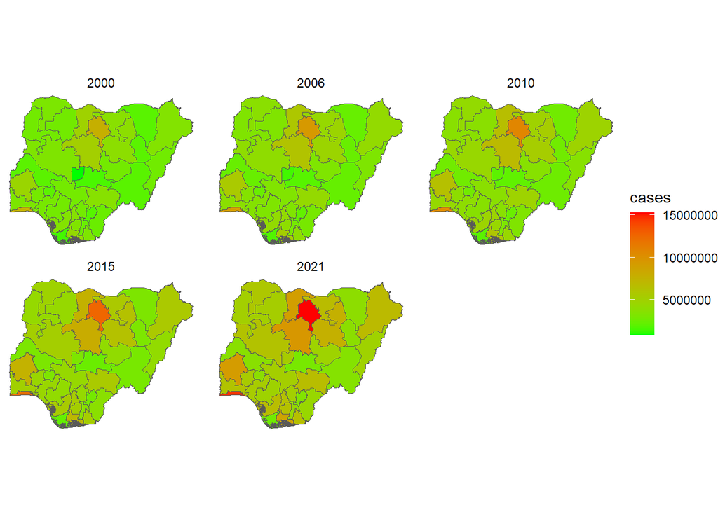

```r
ggplot(data = malaria3_longer) +
  geom_sf(aes(fill = cases)) +
  scale_fill_continuous(low = "green", high = "red") +
  facet_wrap(~ year) +
  theme_void()
```

‣ Ajoutez une autre variable, le risque :

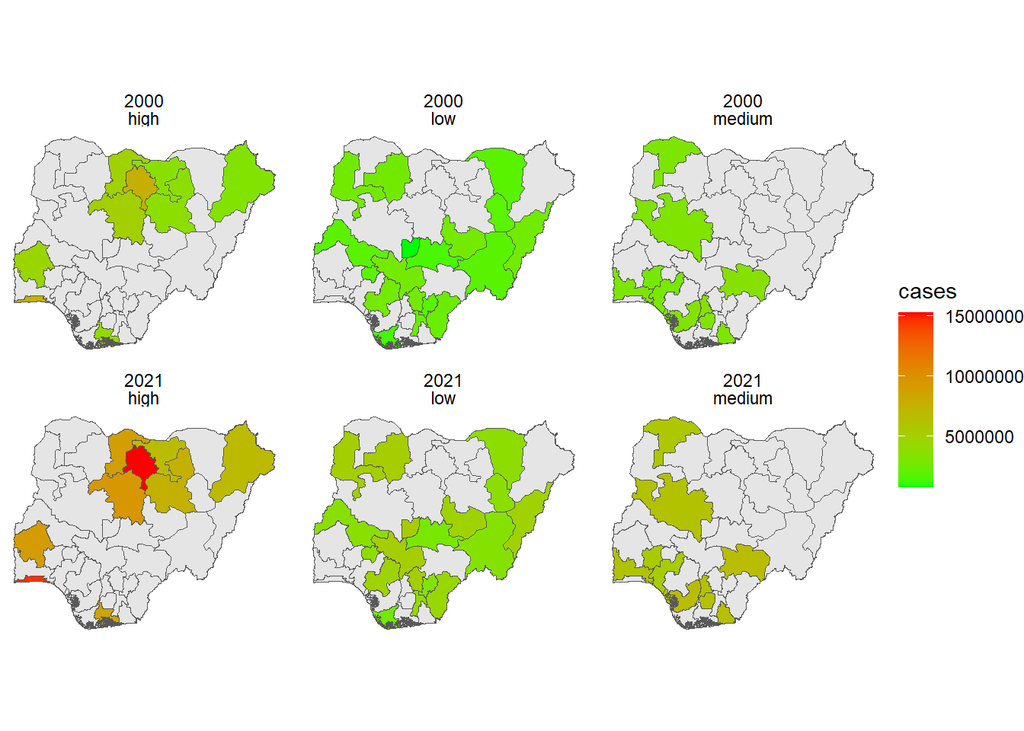

```r
ggplot()+
  geom_sf(data = nga_adm1)+
  geom_sf(aes(fill = cases), data = filter(malaria3_longer, year %in% c("2000", "2021")))+
  facet_wrap(year ~ risk)+
  coord_sf(expand = TRUE)+
  scale_fill_continuous(low = "green", high = "red")+
  theme_void()
```

### 0.9.2 Création de petits multiples avec `facet_grid()`

‣ Utilisez `facet_grid()` pour créer une grille de graphiques.

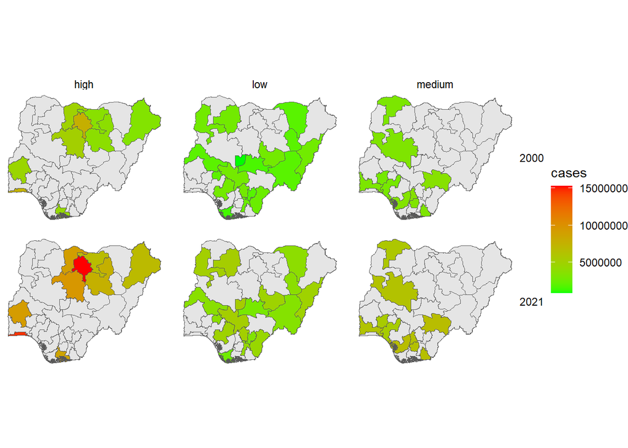

```r
ggplot()+
  geom_sf(data = nga_adm1)+
  geom_sf(aes(fill = cases), data = filter(malaria3_longer, year %in% c("2000", "2021")))+
  facet_grid(year ~ risk)+
  coord_sf(expand = TRUE)+
  scale_fill_continuous(low = "green", high = "red")+
  theme_void()
```

## 0.10 Temps de pratique 3 : Analysez la distribution des cas de paludisme pour 2000 et 2021

‣ Transformez le jeu de données du format large au format long en utilisant `pivot_longer()`.

```r
# Pivotement des données
malaria3_longer <- malaria2 %>%
  pivot_longer(cols = `cases_2000`:`cases_2021`, names_to = "year", values_to = "cases")
```

‣ Catégorisez les données en niveaux de risque en utilisant la médiane (haut/bas).

```r
# Catégorisation du risque basée sur la médiane
malaria3_longer %>%
  mutate(risk = case_when(
    cases >= median(cases) ~ 'haut',
    cases < median(cases) ~ 'bas'
  )) -> malaria3_longer2
```

‣ Nettoyez la colonne des années pour simplifier ses valeurs.

```r
# Nettoyage des valeurs des années
malaria3_longer2$year <- str_replace(malaria3_longer2$year, "cases_", "")
```

‣ Visualisez ces informations sur une carte.

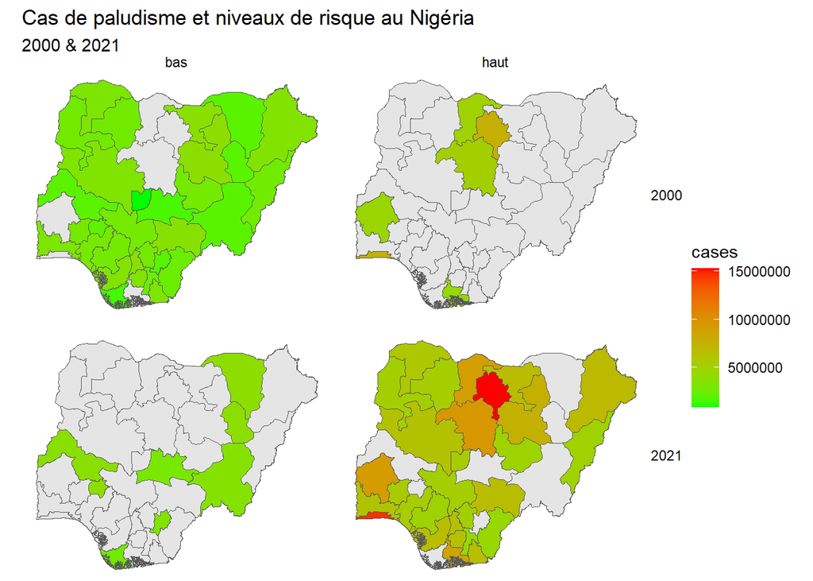

```r
# Tracé des données
ggplot() +
  geom_sf(data = nga_adm1) +
  geom_sf(aes(fill = cases), data = filter(malaria3_longer2, year %in% c("2000", "2021"))) +
  facet_grid(year ~ risk) +
  coord_sf(expand = TRUE) +
  scale_fill_continuous(low = "green", high = "red") +
  labs(title = "Cas de paludisme et niveaux de risque au Nigéria",
       subtitle = "2000 & 2021") +
  xlab("Longitude") +
  ylab("Latitude") +
  theme_void()
```

## Solutions

**1. Construisez votre magnifique carte choroplèthe**

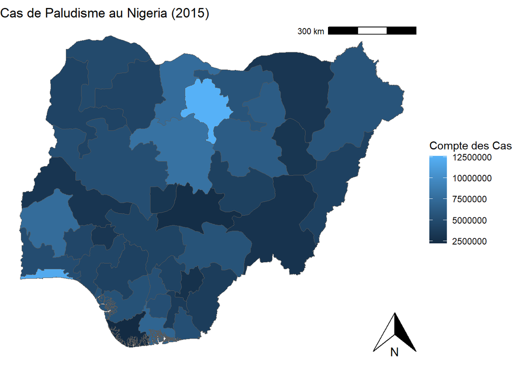

```r
ggplot(data=malaria2) +
  geom_sf(aes(fill=cases_2015)) +
  labs(title = "Cas de Paludisme au Nigeria (2015)",
       fill = "Compte des Cas",
       x = "Longitude",
       y = "Latitude") +
  ggspatial::annotation_north_arrow(location = "br")+
  ggspatial::annotation_scale(location = "tr")+
  theme_void()
```

**2. Créez votre propre palette de couleurs**

Créez votre propre palette de couleurs distincte de celle initialement fournie ci-dessous, et affichez les cas de paludisme à travers le Nigeria pour 2000 en utilisant cette palette de couleurs personnalisée. N’oubliez pas d’incorporer des améliorations esthétiques supplémentaires.

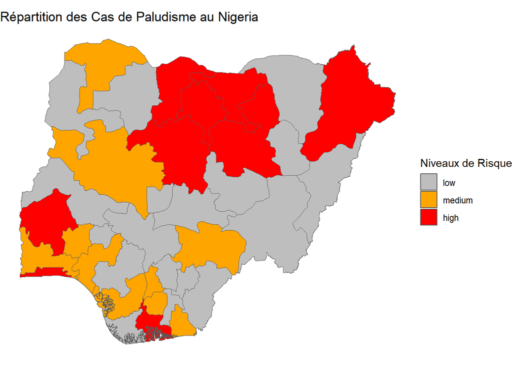

```r
new_palette <- c("grey", "orange", "red") # Définir un ensemble différent de couleurs
ggplot(data=malaria3) +
   geom_sf(aes(fill =  fct_reorder(risk, cases_2000))) + # Réordonner les étiquettes de risque selon les cas de l'année 2000
   scale_fill_manual(values = new_palette, "Niveaux de Risque") +
   labs(title = "Répartition des Cas de Paludisme au Nigeria",
        fill = "Compte des Cas",
        x = "Longitude",
        y = "Latitude") +
   coord_sf(expand = TRUE)+
   theme_void()
```

**3. Analysez la distribution des cas de paludisme**

Votre objectif est maintenant d’analyser la distribution des cas de paludisme au Nigeria pour les années 2000 et 2021. Mais vous devrez d’abord catégoriser les données en niveaux de risque en utilisant la médiane (haut/bas), puis visualiser ces informations sur une carte.

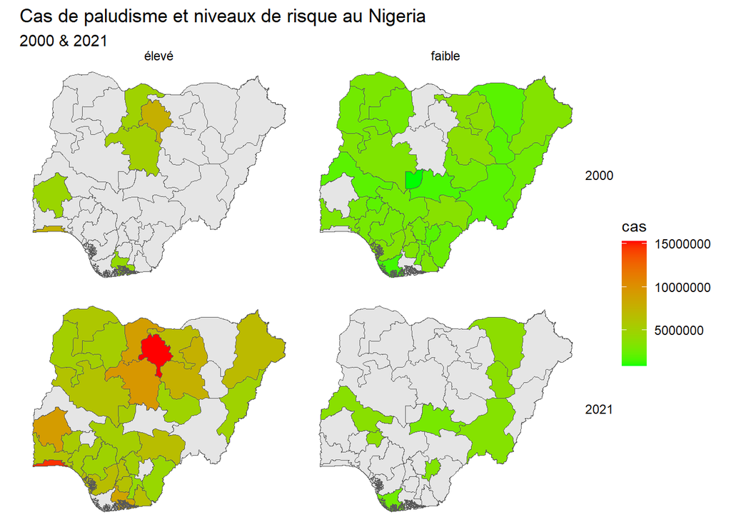

```r
# Pivotement des données
malaria3_longer <- malaria2 %>%
  pivot_longer(cols = `cases_2000`:`cases_2021`, names_to = "année", values_to = "cas")

# Catégorisation du risque basée sur la médiane
malaria3_longer %>%
  mutate(risk = case_when(
    cas <= median(cas) ~ 'faible',
    cas > median(cas) ~ 'élevé'
  )) -> malaria3_longer2

# Nettoyage des valeurs d'année
malaria3_longer2$année <- str_replace(malaria3_longer2$année, "cases_", "")

# Tracé des données
ggplot() +
  geom_sf(data = nga_adm1) +
  geom_sf(aes(fill = cas), data = filter(malaria3_longer2, année %in% c("2000", "2021"))) +
  facet_grid(année ~ risk) +
  coord_sf(expand = TRUE) +
  scale_fill_continuous(low = "green", high = "red") +
  labs(title = "Cas de paludisme et niveaux de risque au Nigeria",
       subtitle = "2000 & 2021") +
  xlab("Longitude") +
  ylab("Latitude") +
  theme_void()
```